# **Natural Language Processing (NLP): Analyzing Social Media Data Using the ‘Bag of Words’ Technique in R**

Can we glean insights from social media posts?

John Karuitha

04 November, 2023

# 1 **Background**

The proliferation of social media platforms has revolutionized the way people communicate, share information, and express opinions in the digital age. These platforms have become an invaluable source of data for researchers, businesses, and policymakers seeking to gain insights into public sentiment, behavior, and trends. Analyzing social media data, however, presents unique challenges due to the unstructured and often noisy nature of text-based content.

The “bag of words” (BoW) technique is a fundamental approach in natural language processing (NLP) that has proven to be highly effective for extracting meaningful information from social media text data. BoW involves converting text data into a matrix of word frequencies, where each unique word is treated as a separate feature. The resulting matrix can be analyzed using various statistical and machine learning methods, making it a versatile tool for text analysis.

One of the key advantages of the BoW technique is its simplicity. It allows for the quantification of textual data without the need for complex linguistic analysis or deep understanding of grammar. This makes it particularly suitable for large-scale text data analysis, which is common in the context of social media.

BoW has been widely applied in sentiment analysis, topic modeling, trend detection, and information retrieval from social media content. Researchers and organizations use it to understand public opinion, monitor brand reputation, detect emerging issues, and improve customer service.

However, the BoW technique also has limitations. It disregards the order of words in a document and may not capture context and nuances effectively. Consequently, it is often used in conjunction with other NLP techniques, such as word embedding and deep learning, to enhance the accuracy of social media data analysis.

In this study, we employ the BoW technique to analyze social media data, seeking to uncover valuable insights and patterns within this rich source of information. By employing BoW in combination with advanced analytics, we aim to extract meaningful knowledge from social media text data, contributing to a deeper understanding of social dynamics, consumer behavior, and emerging trends in the digital landscape.

# 2 **Objectives**

Certainly, here are three objectives focused on identifying the most prevalent words per topic in the context of your analysis:

1. **Topic-Specific Keyword Identification:**

   *Objective*: To identify the most prevalent keywords and terms associated with specific topics within the social media dataset.

   *Rationale*: By utilizing the BoW technique, the objective is to extract and highlight the keywords that are most frequently used within distinct topics. This will enable a comprehensive understanding of the key themes and discussions prevalent in the social media data.
2. **Topic Clustering and Word Distribution Analysis:**

   *Objective*: To cluster social media content into distinct topics and analyze the distribution of the most prevalent words within each cluster.

   *Rationale*: By employing BoW for topic modeling and clustering, the objective is to uncover clusters of related content and examine the distribution of the most prevalent words within each cluster. This approach will provide insights into the main themes and sub-topics dominating the social media conversations.
3. **Content Categorization and Word Frequency Ranking:**

   *Objective*: To categorize social media content based on predefined topics and rank the frequency of words within each category to identify the most prevalent terms.

   *Rationale*: The objective is to use the BoW technique to categorize social media content into relevant topics and determine the frequency of words associated with each category. This approach will facilitate the identification of the most prominent terms characterizing each topic, aiding in comprehensive topic-based analysis and understanding.

# 3 **Loading required packages for the analysis**

I start by loading the required packages for the analysis.

```r
## Load required packages ----
if(!require(pacman)){
        install.packages('pacman')
}

p_load(tidyverse, tm, textclean,
       gt, janitor, ggthemes,
       kableExtra, SnowballC,
       RColorBrewer, wordcloud)

theme_set(ggthemes::theme_clean())
options(digits = 3)
options(scipen = 999)
```

# 4 **Stack Exchange topics and questions**

Over the years, Facebook has hosted multiple competitions on `Kagle` to recruit new employees. This question is based on the third challenge. The original competition tested text mining skills on a large data set from the Stack Exchange sites. The task was to predict the tags (a.k.a. keywords, topics, summaries), given only the question text and its title. The data set contains content from disparate stack exchange sites, containing a mix of both technical and non-technical questions. A sample of this data set has been made available on Canvas, as stack.csv, and this sample provides three columns: the Topic of the post (one of four topics), the Title of the post, and the Body of the post which contains the actual question and explanation. This data set will be used for the rest of the assignment.

```r
## Load the data ----
chats <- read_csv('stack.csv') %>%
        clean_names()
```

## 4.1 Distribution of posts over the various topics

The data set has 2626 observations and 3 variables.

```r
## Topics ----
counts <- chats %>%
        count(topic,
              sort = TRUE,
              name = "Count")
```

```r
## Prevalent topics table ----
counts %>%
        set_names(names(.) %>% str_to_upper()) %>%
        mutate(Prop = COUNT / nrow(chats)) %>%
        gt(caption = "Prevalence of Topics")
```

Prevalence of Topics

| TOPIC | COUNT | Prop |
| --- | --- | --- |
| Facebook | 982 | 0.374 |
| Security | 661 | 0.252 |
| Excel | 617 | 0.235 |
| Firefox | 366 | 0.139 |

The topic about `Facebook` is the most prevalent with 982 entries that accounts for about 37% of the observations. `Security` matters are also prominent with 661 observations (about 25%) of the posts. Posts about `Excel` and `Firefox` are the least prevalent with 617 (24%) and 366 (14%) prevalence, respectively.

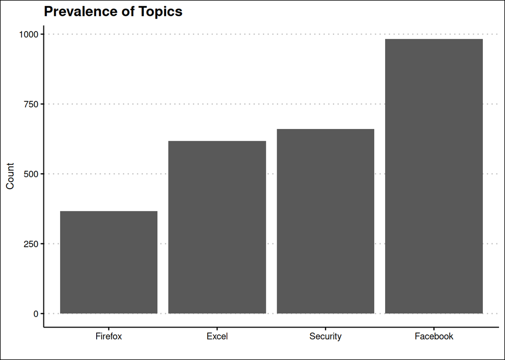

```r
## Prevalent topics ----
counts %>%
        mutate(topic = fct_reorder(topic, Count)) %>%
        ggplot(mapping = aes(x = topic, y = Count)) +
        geom_col() +
        labs(x = "", title = "Prevalence of Topics")
```

## 4.2 Inspecting a couple of question text bodies

The topic section contains HTML tags like <p> and <\p> and URLs for various websites referred to in the text. The text also contains digits that may not be of much use in a text analysis. Moreover, the existence of punctuation and, as in standard grammar, we have a mix of upper case and lower case letters in spelling of words (like at the start of a sentence). This could make two otherwise similar word be different. We also have a lot of special characters (like *, #, @, %) that carry no meaning in text analysis. White spaces, and line breaks are also prevalent. Importantly, we have words that are indispensable in language but that carry no meaning on their own (called stop-words, for example the articles `a` and `the`, among others). p

```r
## Chats body overview ----
chats %>%
        pull(body) %>%
        head(5)
```

```
## [1] "<p>In my favorite editor (vim), I regularly use ctrl-w to execute a certain action. Now, it quite often happens to me that firefox is the active window (on windows) while I still look at vim (thinking vim is the active window) and press ctrl-w which closes firefox. This is not what I want. I…
## [2] "<p>Aloha everyone,</p>\n\n<p>I have a class assignment in which I am tasked to build a MySql database, then use PHP to retrieve the contents of the table in the database.  When I attempt to open this in Safari, it only outputs the HTML/PHP code.  Firefox, on the other hand, pops up a window …
## [3] "<p>I recently started using Firefox as my primary web browser, and I would like to change some of the default keyboard shortcuts, especially the ones used to switch between tabs. Can this be done?</p>\n\n<p>I took a peek through the Firefox directory in \"Application Support\", as well as th…
## [4] "<p>I stepped over the following tutorial:\n<a href=\"http://afana.me/post/create-wizard-in-aspnet-mvc-3.aspx\" rel=\"nofollow\">http://afana.me/post/create-wizard-in-aspnet-mvc-3.aspx</a></p>\n\n<p>Since it looks pretty nice, I'm asking myself if making the complete wizard in JavaScript just…
## [5] "<p>The site is set to WordPress 3.4.1, annexed widget Facebook for WordPress</p>\n\n<p>Later I changed the name to the Facebook user profile, and now get an error that I need to reference a valid Facebook user profile.</p>\n\n<p>What changes do I have to make so that data-href will be the co…
```

### 4.2.1 Issues that need to be solved when cleaning the text later on.

1. HTML Tags: Because the text data comes from web sources, it contains HTML tags. I will remove these tags before commencing analysis.
2. Convert text to lower case: I will convert all text to lowercase to ensure consistency and prevent case-sensitive issues.
3. Punctuation: I will remove all punctuation marks (e.g., periods, commas, quotes) as they may not provide valuable information for analysis.
4. Special Characters: I will eliminate special characters, such as currency symbols or trademark signs, which may not be relevant to our analysis.
5. Stop Words: I will remove common stopwords (e.g., “and,” “the,” “in”) as they often don’t carry significant meaning for analysis. The `tm` package contains the list of the common English stopwords.
6. Numeric Character Removal: Because numbers are not relevant to our analysis, we remove them from the text. This is useful because we are focusing on language and not numerical data.
7. Whitespace and Line Breaks: I will remove extra whites pace and line breaks to ensure uniform formatting of the text before analysis. Without this, white spaces and line breaks could be mistaken for words and hence cloud our analysis.
8. Remove URLs: The text contains web links. I remove these links as they are not relevant to our analysis.
9. Tokenization: I will tokenize the text into words or phrases (tokens) to prepare it for further analysis.
10. Contractions: Some contractions in language complicate the analysis. In that case, I will replace all contractions into standard language (for instance, I’ll to I will).
11. Finally, I will be on the lookout for irrelevant meta data and non-standard character encoding that could affect the analysis.

# 5 **Preparation of the text**

Choose two of the Topics for use in the rest of the assignment. Prepare (cleanse) the question body texts for further analysis by means of the following steps.

I select the following TWO topics;

- Facebook.
- Security.

## 5.1 Using functions from package textclean to remove URLs and make other desired adjustments.

To clean the data, I create a function that will automatically deal with all the issues identified above.

```r
## text cleaning function using text clean ----
text_cleaner <- function(text){
        library(textclean)
        library(tidyverse)
        text %>%
                replace_contraction() %>%
                replace_date(replacement = "") %>%
                replace_email() %>%
                replace_emoji() %>%
                replace_emoticon() %>%
                replace_hash() %>%
                replace_html() %>%
                replace_internet_slang() %>%
                replace_white() %>%
                replace_number(remove = TRUE) %>%
                replace_tag() %>%
                replace_url() %>%
                replace_word_elongation()
}
```

I use the above function to clean the data. I start with the facebook topic data.

```r
## Clean facebook data ----
clean_fb <- chats %>%
        filter(topic == "Facebook") %>%
        select(body) %>%
        text_cleaner()
```

Next, I clean the security topic data.

```r
## Clean security data ----
clean_sec <- chats %>%
        filter(topic == "Security") %>%
        select(body) %>%
        text_cleaner()
```

## 5.2 Building a corpus from the vector with cleansed text;

In this section, I build a corpus and implement several cleansing steps as follow;

1. I remove all the English stopwords as described earlier. These words are important in grammar but carry no meaning on their own.
2. I remove all the numbers as they are not relevant in our text analysis.
3. Further, I eliminate all punctuation. Punctuation does not add value to a text analysis.
4. Next, I convert all text to lower case so that case sensitivity does not negatively affect our analysis.
5. Finally, I strip all the extra white spaces between words.

I then convert the output into a term document matrix.

```r
## Create a document term matrix for facebook topic ----
fb_dtm <- clean_fb %>%
        VectorSource() %>%
        Corpus() %>%
        tm_map(removeWords, stopwords('english')) %>%
        tm_map(removeNumbers) %>%
        tm_map(removePunctuation) %>%
        tm_map(tolower) %>%
        tm_map(stripWhitespace) %>%
        tm_map(stemDocument) %>%
        TermDocumentMatrix()
```

```r
## Create a document term matrix for security topic ----
sec_dtm <- clean_sec %>%
        VectorSource() %>%
        Corpus() %>%
        tm_map(removeWords, stopwords('english')) %>%
        tm_map(removeNumbers) %>%
        tm_map(removePunctuation) %>%
        tm_map(tolower) %>%
        tm_map(stripWhitespace) %>%
        tm_map(stemDocument) %>%
        TermDocumentMatrix()
```

## 5.3 Number of words and documents in the resulting corpus for each Topic.

The facebook topic consists of one document with 9517 terms. There is zero sparse terms, meaning that each of the terms appears at least once. The maximal term length is 368.

```r
## Documents and term counts in facebook topic ----
fb_dtm
```

```
## <<TermDocumentMatrix (terms: 9517, documents: 1)>>
## Non-/sparse entries: 9517/0
## Sparsity           : 0%
## Maximal term length: 368
## Weighting          : term frequency (tf)
```

```r
## Documents and term counts in security topic ----
sec_dtm
```

```
## <<TermDocumentMatrix (terms: 8647, documents: 1)>>
## Non-/sparse entries: 8647/0
## Sparsity           : 0%
## Maximal term length: 676
## Weighting          : term frequency (tf)
```

# 6 **Popular associates**

For each of your chosen Topic, make an overview of the most frequent terms in the corpus and make an overview of the terms that have the higher correlations with that Topic. Comment on the results. Speculate as to whether there is possible predictive value in these results. [0.5 page]

In each case, I pick the terms that occur at least 400 times, starting with the Facebook topic below.

```r
## Popular terms- facebook ----
fb_dtm %>%
        findFreqTerms(lowfreq = 400) %>%
        head(30)
```

```
##  [1] "app"      "can"      "code"     "facebook" "frown"    "get"
##  [7] "like"     "page"     "pnn"      "post"     "skeptic"  "stick"
## [13] "tongu"    "tri"      "use"      "user"     "work"
```

Next, we look at the security topic.

```r
## Popular terms- security ----
sec_dtm %>%
        findFreqTerms(lowfreq = 400) %>%
        head(30)
```

```
## [1] "can"     "frown"   "secur"   "server"  "skeptic" "stick"   "tongu"
## [8] "use"     "user"
```

We see a clear distinction in the terms occurring in both topics. For the security topic, the terms `secur` has a high association with the topic. For Facebook, the term `facebook`, `app` have a high correlation with the topic. In our case, the terms “can”, “skeptic”, “use”, and “User” have little predictive value in topic modelling. Overall, the output has some predictive power as there are words that clearly stand out in each of the topics. For instance, the term `server` is highly related to the security topic but is not among the top terms in the facebook topic. Likewise, the term `page` is more prevalent in the facebook topic than in the security topic. Such prevalence of terms gives rise the data some predictive power.

# 7 **Word clouds**

Make a word cloud for each of your chosen Topic, and include these in your report. Compare the two graphs and discuss the result. [0.5 page]

Other terms that stand out in the facebook topic.

- Like.
- Page.
- frown.

Other terms that stand out in the security topic.

- Server.
- Password.
- Access.
- Data.

Terms that overlap in both topics include, among others the following:

- Use.
- User.
- Code.
- Skeptic.

### 7.0.1 World Cloud for Facebook Topic

```r
## Wordcloud- facebook ----
fb_df <- fb_dtm %>%
        as.matrix() %>%
        data.frame() %>%
        set_names("Count") %>%
        mutate(Term = row.names(.)) %>%
        arrange(desc(Count))
```

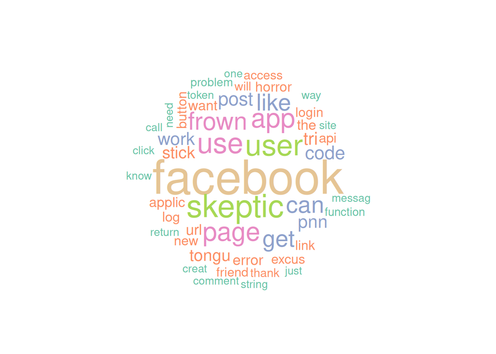

WordCloud for the Facebook Topic

```r
## Word cloud for facebook topic
wordcloud(
        words = fb_df$Term,
        freq = fb_df$Count,
         min.freq=1,
         max.words = 50,
         random.order = FALSE,
         colors=brewer.pal(7, "Set2"))
```

### 7.0.2 World Cloud for Security Topic

```r
## Wordcloud- security ----
sec_df <- sec_dtm %>%
        as.matrix() %>%
        data.frame() %>%
        set_names("Count") %>%
        mutate(Term = row.names(.)) %>%
        arrange(desc(Count))
```

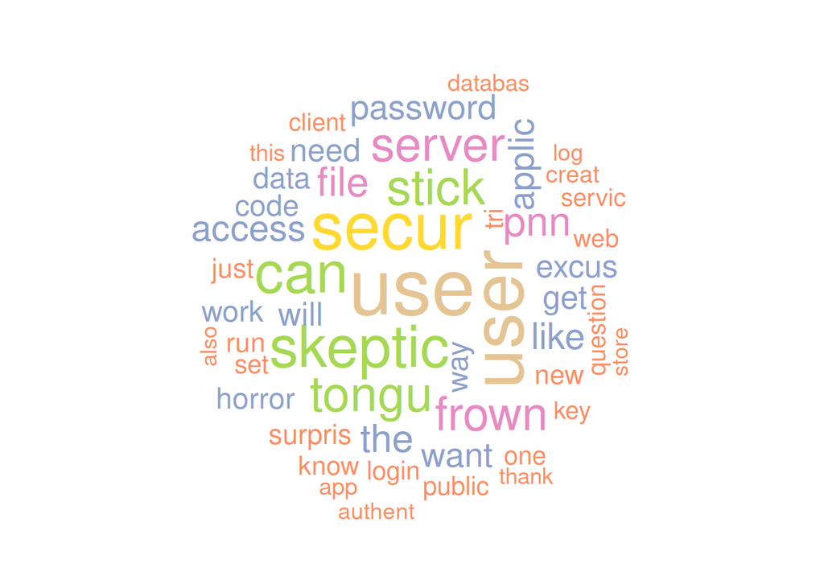

WordCloud for the Security Topic

```r
## Word cloud for security topic
wordcloud(
        words = sec_df$Term,
        freq = sec_df$Count,
         min.freq=1,
         max.words = 50,
         random.order = FALSE,
         colors=brewer.pal(7, "Set2"))
```

# 8 **Conclusion**

**Conclusion:**

# 9 **References**

Banks, G. C., Woznyj, H. M., Wesslen, R. S., & Ross, R. L. (2018). A review of best practice recommendations for text analysis in R (and a user-friendly app). **Journal of Business and Psychology**, 33, 445-459.

Welbers, K., Van Atteveldt, W., & Benoit, K. (2017). Text analysis in R. **Communication methods and measures**, 11(4), 245-265.

# 10 **Code Appendix**

```
## ----setup, include=FALSE----------------------------------------------------------------------------
knitr::opts_chunk$set(echo = FALSE, warning = FALSE, message = FALSE)



## ----echo = TRUE-------------------------------------------------------------------------------------
## Load required packages ----
if(!require(pacman)){
        install.packages('pacman')
}

p_load(tidyverse, tm, textclean,
       gt, janitor, ggthemes,
       kableExtra, SnowballC,
       RColorBrewer, wordcloud)

theme_set(ggthemes::theme_clean())
options(digits = 3)
options(scipen = 999)


## ----------------------------------------------------------------------------------------------------
## Load the data ----
chats <- read_csv('stack.csv') %>%
        clean_names()


## ----------------------------------------------------------------------------------------------------
## Topics ----
counts <- chats %>%
        count(topic,
              sort = TRUE,
              name = "Count")



## ----------------------------------------------------------------------------------------------------
## Prevalent topics table ----
counts %>%
        set_names(names(.) %>% str_to_upper()) %>%
```

[output cut: 133 more lines]

```
sec_df <- sec_dtm %>%
        as.matrix() %>%
        data.frame() %>%
        set_names("Count") %>%
        mutate(Term = row.names(.)) %>%
        arrange(desc(Count))

## Word cloud for security topic ----
wordcloud(
        words = sec_df$Term,
        freq = sec_df$Count,
         min.freq=1,
         max.words = 50,
         random.order = FALSE,
         colors=brewer.pal(7, "Set2"))
```